# Wittenberg University: ANLT 510

## Exercise 4.12

**This problem involves writing functions.**

1. **Write a function, `Power()`, that prints out the result of raising 2 to the 3rd power. In other words, your function should compute $2^3$ and print out the results.**

```r
Power <- function() {
  2^3
}

Power()
```

```
## [1] 8
```

2. **Create a new function, `Power2()`, that allows you to pass any two numbers, “$x$” and “$a$”, and prints out the value of “$x^a$”.**

```r
Power2 <- function(x = 3, a = 7){
  x ^ a
}

Power2()
```

```
## [1] 2187
```

```r
Power2(5,8)
```

```
## [1] 390625
```

3. **Using the `Power2()` function that you just wrote, compute $10^3$, $81^7$, and $131^3$.**

```r
Power2(10, 3)
```

```
## [1] 1000
```

```r
Power2(81, 7)
```

```
## [1] 2.287679e+13
```

```r
Power2(131, 3)
```

```
## [1] 2248091
```

4. **Now create a new function, `Power3()`, that actually returns the result “$x^a$” as an R object, rather than simply printing it to the screen. That is, if you store the value “$x^a$” in an object called “result” within your function, then you can simply `return()` this result.**

```r
Power3 <- function(x = 3, a = 7){
  return(x^a)
}
ans = Power3()

ans
```

```
## [1] 2187
```

5. **Now using the `Power3()` function, create a plot of $f(x)=x^3$. The x-axis should display a range of integers from 1 to 10, and the y-axis should display $x^3$. Label the axes appropriately, and use an appropriate title for the figure. Consider displaying either the x-axis, the y-axis, or both on the log-scale.**

```r
x <- 1:10
y <- Power3(x, a = 3)
x;y
```

```
##  [1]  1  2  3  4  5  6  7  8  9 10
```

```
##  [1]    1    8   27   64  125  216  343  512  729 1000
```

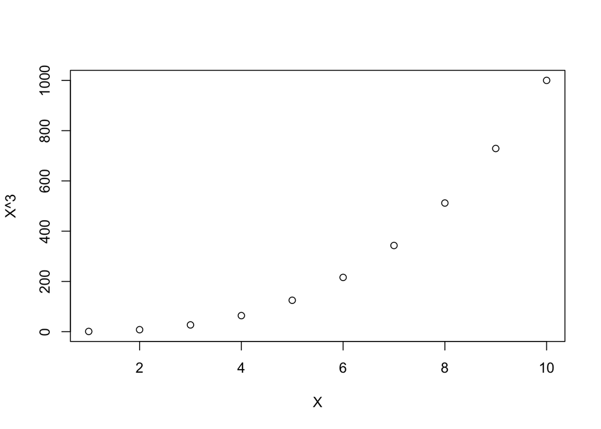

```r
plot(x=x,
     y=y,
     xlab = "X",
     ylab = "X^3")
```

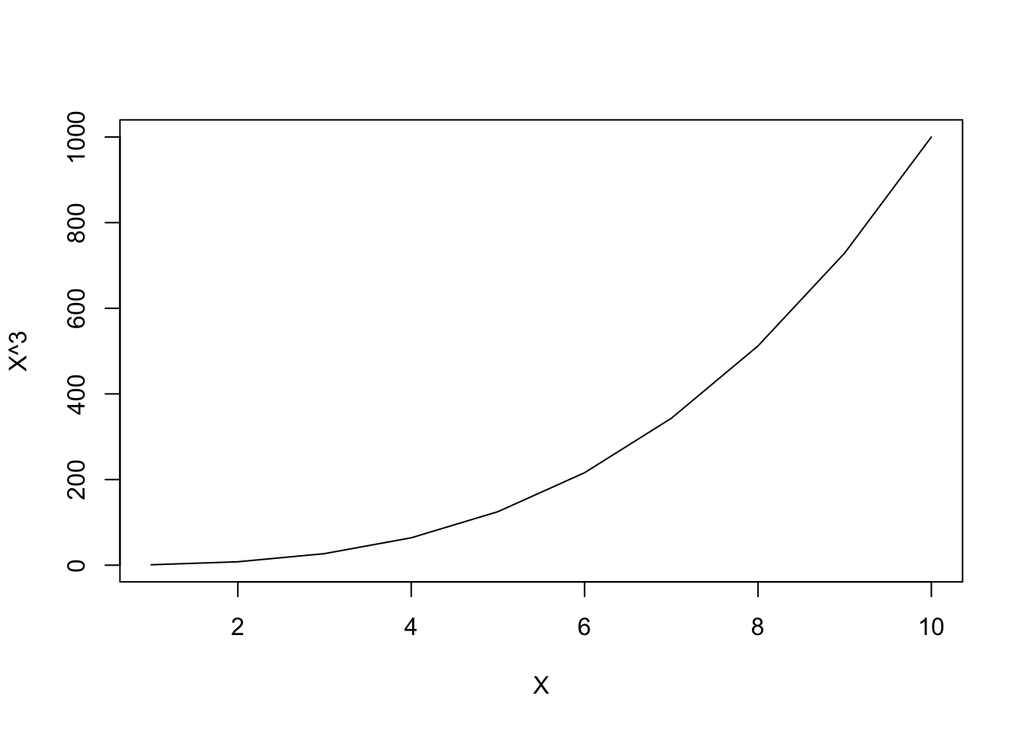

```r
plot(x=x,
     y=y,
     xlab = "X",
     ylab = "X^3",
     type = "l")
```

6. **Create a function, `PlotPower()`, that allows you to create a plot of “$x$” against “$x^a$” for a fixed “$a$” and for a range of values of “$x$”.**

[figure not shown]

```r
PlotPower <- function(x,a){
  y = x^a
  plot(x=x,
       y=y,
      xlab = "X",
      ylab = "X^3")
}
PlotPower(x = 1:10, a = 30)
```